中文 Text Mining 的前處理比起其它以拉丁字母為主的文本困難許多，參考資源也相對龐雜不全。 這裡以較晚近出現的[`quanteda`](https://quanteda.io/)套件為根據，依其需求進行中文文本前處理。

選擇 `quanteda`而非其它較流行的套件如`tm`的原因是因為其[多語言支持](https://github.com/quanteda/stopwords)較佳，譬如其內建的 tokenizer 能直接對中文進行斷詞。然而，由於 [`jieba`](https://github.com/fxsjy/jieba)的社群資源以及斷詞效果較佳，此文還是以[`jiebaR`](https://github.com/qinwf/jiebaR)進行斷詞。

此外，因為使用的語料是簡體字，這裡也提到簡體、繁體轉換處理的相關資源。 我希望這篇文章能整理出一套中文文本前處理的架構，試圖減輕未來可能遇到的問題。

上次更新：2018-07-29

## 流程

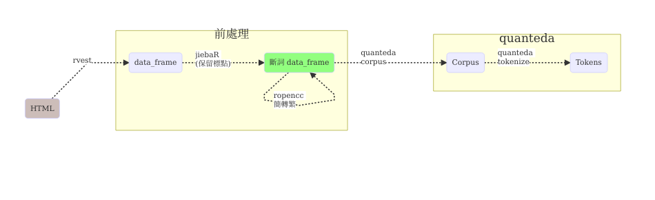

## 資料爬取

這邊使用[謝益輝](https://yihui.name/en/about/)的中文[部落格](https://yihui.name/cn/)文章作為練習素材。首先需要取得文章的網址，因此先到部落格的文章列表頁面(https://yihui.name/cn/)，使用瀏覽器的[開發者工具](https://developers.google.com/web/tools/chrome-devtools/?hl=zh-tw)(按`Ctrl + Shift + I`開啟)進行**觀察**。

接著使用[`rvest`](https://github.com/hadley/rvest)套件擷取網頁中所有文章的連結，並將文章網址儲存成`list_of_post.txt`：

```r
library(dplyr)
library(rvest)

list_of_posts <- read_html("https://yihui.name/cn/") %>%
    html_nodes(".archive") %>% # 列表在 div.archive 之下
    html_nodes("p") %>% # 文章標題在 <div> 下之 <p>
    html_nodes("a") %>% html_attr("href") # 文章連結在 <p> 下之 <a>

readr::write_lines(list_of_posts, "yihui/list_of_post.txt")
```

```r
head(list_of_posts, 2)
```

```
[1] "/cn/2018/07/lost-bow/"     "/cn/2018/07/fluent-essay/"
```

```r
tail(list_of_posts, 2)
```

```
[1] "/cn/2005/01/rtx/"      "/cn/2005/01/20-13-00/"
```

```r
length(list_of_posts)
```

```
[1] 1032
```

可以看到總共有 1032 篇文章，時間從 2005 年到今年七月都有發文的紀錄。

由於文章數量相當多，因此之後僅會下載部分文章，**避免造成伺服器負擔過大**。下載網頁時，可以在 R 中直接使用`rvest`(見下文**資料前處理**)，但我比較建議使用 Bash[^1]的`wget`指令，才不會因為重複下載網頁造成伺服器負擔。

在下載前，需先決定目標文章的網址`sub_list`：

```r
library(stringr)
set.seed(2018) # 設隨機種子 固定隨機函數的結果

idx <- str_detect(list_of_posts, "2018|2015|2010")
sub_list <- list_of_posts[idx]
sub_list <- sub_list[sample(seq_along(sub_list), 20)]  %>% # 抽出 20 篇
    str_replace_all(pattern = "^/", # 將站內連結改為完整 url
                    replacement = "https://yihui.name/") %>%
    str_replace_all(pattern = "/$", "/index.html")

readr::write_lines(sub_list, "yihui/sublist.txt")

# 給 Bash 用的
sub_list %>%
    str_replace_all("https://yihui.name/cn/", "") %>%
    str_replace_all("/index.html", "") %>%
    str_replace_all("/", "-") %>%
    str_replace_all("-$", "") %>%
    readr::write_lines("yihui/sublist_name.txt")
```

### Bash 指令下載網頁

> 無法使用 bash 指令者，可跳過此節

為了自動化下載網頁，我寫了一個簡單的 Bash script `wget_list`，用法如下:

- `wget_list <網址文字檔> <檔名文字檔>`[^2]
  - `<網址文字檔>`： 每一列(row)由一個網址組成
  - `<檔名文字檔>`： 每一列由一個名稱組成，每個名稱與`<網址文字檔>`的網址對應

在這裡，執行下列指令即可下載網頁

```bash
cd yihui/html
wget_list ../sublist.txt ../sublist_name.txt
cd -
```

**`wget_list`**:

```bash
#!/bin/bash

#<<< wget_list: dowload webpages listed in a file >>>#
### Argument 1 is the file of links, 1 url per row   ###
### Argument 2 is the file of names, 1 name per row  ###

file1=$1
file2=$2

## Get the number of lines in the link list
num_lines=$(wc -l $file1 | egrep -o '^[0-9]*')

## loop over the lines in file1, dowload the the file & name them as listed in file2
for (( i=1; i<=${num_lines}; ++i )); do
     wget "$(sed -n ${i}p $file1)" \
         -O "$(sed -n ${i}p $file2)"
done
```

## 資料前處理

在清理資料之前，需先剖析網頁結構(就如同之前剖析文章列表頁面一樣)。 這邊觀察[這篇文章](https://yihui.name/cn/2015/11/peer-review/)，大致可以找出這些資訊：

```r
path <- "https://yihui.name/cn/2015/11/peer-review/"
all <- read_html(path) %>%
    html_nodes("article")
header <- all %>% html_nodes("header")

title <- header %>%      # 文章標題
    html_nodes("h1") %>% html_text()

post_date <- header %>%  # 發文日期
    html_node("h3") %>% html_text() %>%
    str_extract("201[0-9]-[0-9]{2}-[0-9]{2}")

article <- all %>%       # 內文
    html_nodes("p") %>%
    html_text() %>% paste(collapse = "\n")
    # 這裡將 chr vector collapse 至 1 個字串，
    # 簡化資料結構，並以分行符號保留段落資訊

num_sec <- all %>%      # 內文段落數
    html_nodes("p") %>% length

links <- all %>% html_nodes("p") %>% # 內文連結
    html_nodes("a") %>% html_attr("href")
link_text <- all %>% html_nodes("p") %>% # 內文連結標題
    html_nodes("a") %>% html_text()
```

```r
library(tibble)
df <- data_frame(title = title,
           date = post_date,
           content = article,
           num_sec = num_sec,
           links = list(links),
           link_text = list(link_text)
           )
df %>%
    mutate(title = str_trunc(title, 8),
           content = str_trunc(content, 8),
           links = str_trunc(links, 8),
           link_text = str_trunc(link_text, 8)) %>%
    kable("markdown", align = "c")
```

| title | date | content | num_sec | links | link_text |
| --- | --- | --- | --- | --- | --- |
| 同行评审 | 2015-11-11 | 看到这么一… | 8 | c(“ht… | c(“一则… |

我們可以將上面的程式碼改寫成函數`post_data()`，自動讀取文章並輸出 data frame：

```r
post_data <- function (path) {
    all <- read_html(path) %>%
        html_nodes("article")
    header <- all %>% html_nodes("header")

    title <- header %>%      # 文章標題
        html_nodes("h1") %>% html_text()

    post_date <- header %>%  # 發文日期
        html_node("h3") %>% html_text() %>%
        str_extract("201[0-9]-[0-9]{2}-[0-9]{2}")

    article <- all %>%       # 內文
        html_nodes("p") %>%
        html_text() %>% paste(collapse = "\n")
        # 這裡將 chr vector collapse 至 1 個字串，
        # 簡化資料結構，並以分行符號保留段落資訊

    num_sec <- all %>%      # 內文段落數
        html_nodes("p") %>% length

    links <- all %>% html_nodes("p") %>% # 內文連結
        html_nodes("a") %>% html_attr("href")
    link_text <- all %>%     # 內文連結標題
        html_nodes("p") %>%
        html_nodes("a") %>% html_text()

    df <- tibble::data_frame(title = title,
                             date = post_date,
                             content = article,
                             num_sec = num_sec,
                             links = list(links),
                             link_text = list(link_text)
                             )
}
```

接著，將所有文章讀取至一個 data frame `all_post`：

```r
library(dplyr)
library(tidyr)

html_list <- list.files("yihui/html/") # 列出資料夾下的檔案
all_post <- vector("list", length(html_list))

for (i in seq_along(html_list)) {
    path <- paste0("yihui/html/", html_list[i])
    all_post[[i]] <- post_data(path)
}

all_post <- bind_rows(all_post) %>% arrange(desc(date))

head(all_post) %>%
    mutate(title = str_trunc(title, 8),
           content = str_trunc(content, 8),
           links = str_trunc(links, 8),
           link_text = str_trunc(link_text, 8)) %>%
    kable("markdown", align = "c")
```

| title | date | content | num_sec | links | link_text |
| --- | --- | --- | --- | --- | --- |
| 修辞还是真实 | 2018-06-21 | 说两封让我… | 12 | chara… | chara… |
| 花椒香料 | 2018-05-31 | 古人似乎喜… | 2 | /cn/2… | 去年的花椒 |
| CSS 的… | 2018-05-14 | CSS 中… | 15 | c(“ht… | c(“查阅… |
| 毛姆的文学回忆录 | 2018-05-04 | 前段时间看… | 14 | c(“/c… | c(“职业… |
| 距离的组织 | 2018-05-03 | 前面《闲情… | 5 | /cn/2… | 闲情赋 |
| 语言圣战的终结？ | 2018-04-19 | 一直以来我… | 3 | c(“ht… | c(“惊天… |

### 直接從網路讀取

如果無法使用 Bash 指令下載網頁，可將上面程式碼的`html_list`改為讀取`sublist.txt`中的 url，並修改`for`迴圈中的`path`：

```r
html_list <- read_lines("yihui/sublist.txt") # 讀取 url
all_post <- vector("list", length(html_list))

for (i in seq_along(html_list)) {
    path <- html_list[i]
    all_post[[i]] <- post_data(path)
}

all_post <- bind_rows(all_post) %>% arrange(desc(date))
```

### 斷詞

在處理中文、日語等文本資料，需先經過斷詞處理，因為其不像英語等歐洲語言的文本，以空格表示字詞的界線。

我們將使用`jiebaR`套件的`segment()`進行斷詞。由`?segment()`查看其 documentation 可知**`segment()`只吃文字檔或 一個句子**，因此需先搞清楚`all_post`的結構才能進行斷詞：

`all_post$content`的結構相當簡單(一篇文章一個字串)，因此不須經過額外處理。其它變項不須斷詞處理，因此在此不加細談。

#### jiebaR::segment (optional)

因為`all_post$content`簡單的結構符合`jiebaR`套件的預設需求，但有時資料會比較複雜，因此記錄下來供未來參考。

前面提到`jiebaR::segment`只吃一個句子(一個字串)或文字檔，那如果丟一個 vector 給它會怎樣？答案是看`worker()`的設定：

```r
library(jiebaR)
seg <- worker(symbol = T, bylines = F)
segment(c("妳很漂亮", "我不喜歡你"), seg)
```

```
[1] "妳"     "很漂亮" " "      "我"     "不"     "喜歡"   "你"
```

```r
seg <- worker(symbol = T, bylines = T)
segment(c("妳很漂亮", "我不喜歡你"), seg)
```

```
[[1]]
[1] "妳"     "很漂亮"

[[2]]
[1] "我"   "不"   "喜歡" "你"
```

1. `bylines = F`：回傳 1 個 chr vector，其每個元素為 1 個詞。
2. `bylines = T`：回傳 1 個 list，其長度(元素的數量)等於輸入之 vector 的長度，每個元素為一個 chr vector。

`bylines = F`的設定在此符合我們的需求，並且為配合`quanteda`套件的特性而將斷詞結果以一個字串(以空格分開字詞)而非一個 chr vector 的形式儲存。 以下**對第一篇文章進行斷詞**：

```r
library(jiebaR)
all_post_seg <- all_post
seg <- worker(symbol = T, bylines = F)

all_post_seg$content[1] <- all_post$content[1] %>%
    segment(seg) %>% paste(collapse = " ")

all_post$content[1] %>% str_trunc(20)
```

```
[1] "说两封让我感到“我天，给亲友的书信..."
```

```r
all_post_seg$content[1] %>% str_trunc(30)
```

```
[1] "说 两封 让 我 感到 “ 我 天 ， 给 亲友 的 ..."
```

要處理所有文章，僅需外包一個 for loop：

```r
all_post_seg <- all_post
seg <- worker(symbol = T, bylines = F)

idx <- seq_along(all_post$content)
for (i in idx){
    all_post_seg$content[i] <- all_post$content[i] %>%
        segment(seg) %>% paste(collapse = " ")
}

head(all_post$content, 3) %>% str_trunc(20)
```

```
[1] "说两封让我感到“我天，给亲友的书信..."
[2] "古人似乎喜欢把花椒当香料用。在《古..."
[3] "CSS 中的位置（position..."
```

```r
head(all_post_seg$content, 3) %>% str_trunc(30)
```

```
[1] "说 两封 让 我 感到 “ 我 天 ， 给 亲友 的 ..."
[2] "古人 似乎 喜欢 把 花椒 当 香料 用 。 在 《 ..."
[3] "CSS   中 的 位置 （ position ） 属..."
```

### 簡轉繁

OpenCC 是一個簡體字與繁體字轉換的專案，非常優秀，因為其不僅是單純字轉字，甚至處理了地區性的用法(如「軟體」vs.「软件」)。因此，其簡繁轉換的選項有非常多：

- `s2t.json` Simplified Chinese to Traditional Chinese 簡體到繁體
- `t2s.json` Traditional Chinese to Simplified Chinese 繁體到簡體
- `s2tw.json` Simplified Chinese to Traditional Chinese (Taiwan Standard) 簡體到臺灣正體
- `tw2s.json` Traditional Chinese (Taiwan Standard) to Simplified Chinese 臺灣正體到簡體
- `s2hk.json` Simplified Chinese to Traditional Chinese (Hong Kong Standard) 簡體到香港繁體（香港小學學習字詞表標準）
- `hk2s.json` Traditional Chinese (Hong Kong Standard) to Simplified Chinese 香港繁體（香港小學學習字詞表標準）到簡體
- `s2twp.json` Simplified Chinese to Traditional Chinese (Taiwan Standard) with Taiwanese idiom 簡體到繁體（臺灣正體標準）並轉換爲臺灣常用詞彙
- `tw2sp.json` Traditional Chinese (Taiwan Standard) to Simplified Chinese with Mainland Chinese idiom 繁體（臺灣正體標準）到簡體並轉換爲中國大陸常用詞彙
- `t2tw.json` Traditional Chinese (OpenCC Standard) to Taiwan Standard 繁體（OpenCC 標準）到臺灣正體
- `t2hk.json` Traditional Chinese (OpenCC Standard) to Hong Kong Standard 繁體（OpenCC 標準）到香港繁體（香港小學學習字詞表標準）

[`ropencc`](https://github.com/qinwf/ropencc)套件是 OpenCC 的 R 語言接口，其不在 CRAN 上，需以`devtools`從 GitHub 下載：

```r
devtools::install_github("qinwf/ropencc")
```

使用上非常容易：

```r
library(ropencc)
trans <- converter(TW2SP) # 臺灣用法轉大陸用法
run_convert(trans, "開放中文轉換軟體")
```

```
[1] "开放中文转换软件"
```

```r
trans <- converter(T2S)   # 單純繁轉簡
run_convert(trans, "開放中文轉換軟體")
```

```
[1] "开放中文转换软体"
```

```r
trans <- converter(S2TWP) # 簡轉臺灣用法
run_convert(trans, "开放中文转换软件")
```

```
[1] "開放中文轉換軟體"
```

在此我們使用`S2TWP`轉換`all_post_seg$content`、`S2T`轉換`all_post_seg$title`：

```r
library(ropencc)
all_post_seg$content <- run_convert(converter(S2TWP),
                                    all_post_seg$content)
all_post_seg$title <- run_convert(converter(S2T),
                                  all_post_seg$title)

head(all_post_seg) %>%
    mutate(title = str_trunc(title, 8),
           content = str_trunc(content, 8),
           links = str_trunc(links, 8),
           link_text = str_trunc(link_text, 8)) %>%
    kable("markdown", align = "c")
```

| title | date | content | num_sec | links | link_text |
| --- | --- | --- | --- | --- | --- |
| 修辭還是真實 | 2018-06-21 | 說 兩封 … | 12 | chara… | chara… |
| 花椒香料 | 2018-05-31 | 古人 似乎… | 2 | /cn/2… | 去年的花椒 |
| CSS 的… | 2018-05-14 | CSS … | 15 | c(“ht… | c(“查阅… |
| 毛姆的文學回憶錄 | 2018-05-04 | 前段時間 … | 14 | c(“/c… | c(“职业… |
| 距離的組織 | 2018-05-03 | 前面 《 … | 5 | /cn/2… | 闲情赋 |
| 語言聖戰的終結？ | 2018-04-19 | 一直 以來… | 3 | c(“ht… | c(“惊天… |

## quanteda

```r
library(quanteda)
corp <- corpus(all_post_seg,
               docid_field = "title",
               text_field = "content")

corp %>% summary() %>% as_data_frame() %>%
    head() %>%
    mutate(links = str_trunc(links, 8),
           link_text = str_trunc(link_text, 8)) %>%
    kable("markdown", align = "c")
```

| Text | Types | Tokens | Sentences | date | num_sec | links | link_text |
| --- | --- | --- | --- | --- | --- | --- | --- |
| 修辭還是真實 | 217 | 375 | 15 | 2018-06-21 | 12 | chara… | chara… |
| 花椒香料 | 149 | 246 | 9 | 2018-05-31 | 2 | /cn/2… | 去年的花椒 |
| CSS 的位置屬性以及如何居中對齊超寬元素 | 347 | 805 | 23 | 2018-05-14 | 15 | c(“ht… | c(“查阅… |
| 毛姆的文學回憶錄 | 489 | 956 | 28 | 2018-05-04 | 14 | c(“/c… | c(“职业… |
| 距離的組織 | 212 | 380 | 23 | 2018-05-03 | 5 | /cn/2… | 闲情赋 |
| 語言聖戰的終結？ | 169 | 249 | 9 | 2018-04-19 | 3 | c(“ht… | c(“惊天… |

## 附註

[^1]: Mac 和 Linux 內建有 Bash，但 Windows 沒有。
[^2]: 要能直接執行`wget_list`需先給予其執行的權限，因此需設置`chmod 755 <path to wget_list>`，並且將`wget_list`置於 shell 會自動搜尋程式的地方(如`/usr/bin/`)。

    另一個方法是不設置權限，直接執行`wget_list`：  
    `bash <path to wget_list> <file1> <file2>`